# BUA 455 - Week 2: Intro dplyr & ggplot

### Why do we do these data management tasks?

- Filtering data to a subset by value
- Slicing data by row number
- Selecting variables
- Removing missing values
- Creating new variables

These are all the most common tasks that are done to raw data to make it **usable**.

**Usable** data can communicate information:

- Can be summarized in a table for presentation
- Can be visualized in a plot
- Can be analyzed using statistical models
- Can be presented or published

In the next demonstration:

We examine how these managed data are **USED** to create a simple plot that is then formatted for presentation.

### Basic boxplot (Two Code Formats)

#### Format 1:

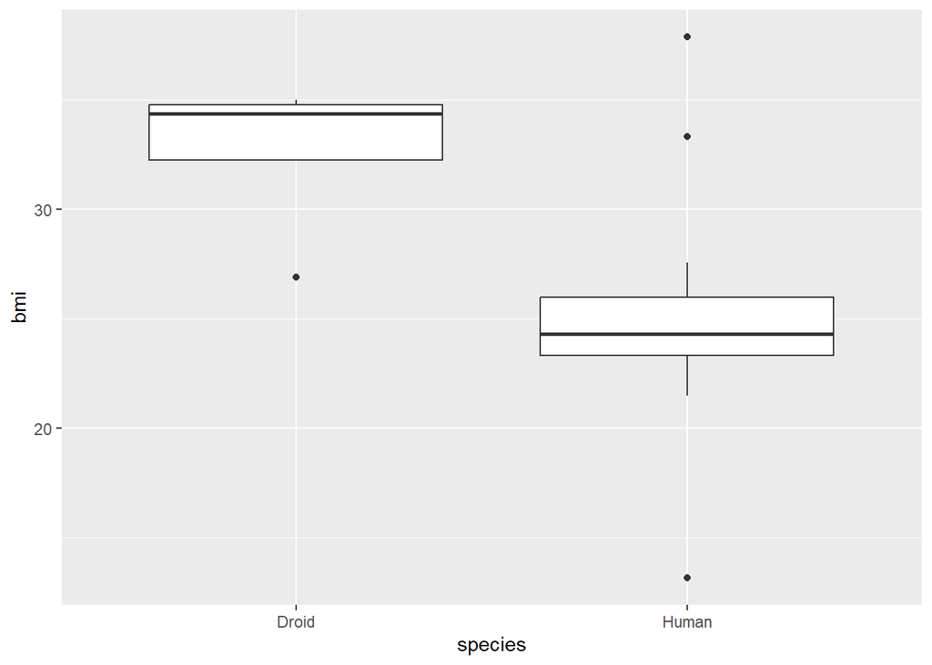

```r
# useful for simple plots
my_starwars_plt |>
  ggplot() +
  geom_boxplot(aes(x=species, y=bmi))
```

#### Format 2:

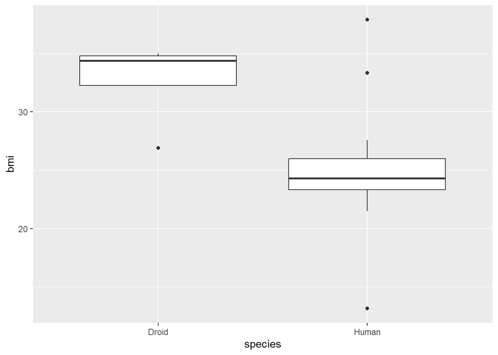

```r
# useful for overlaying plot features
my_starwars_plt |>
  ggplot(aes(x=species, y=bmi)) +
  geom_boxplot()
```

### Saved Plot

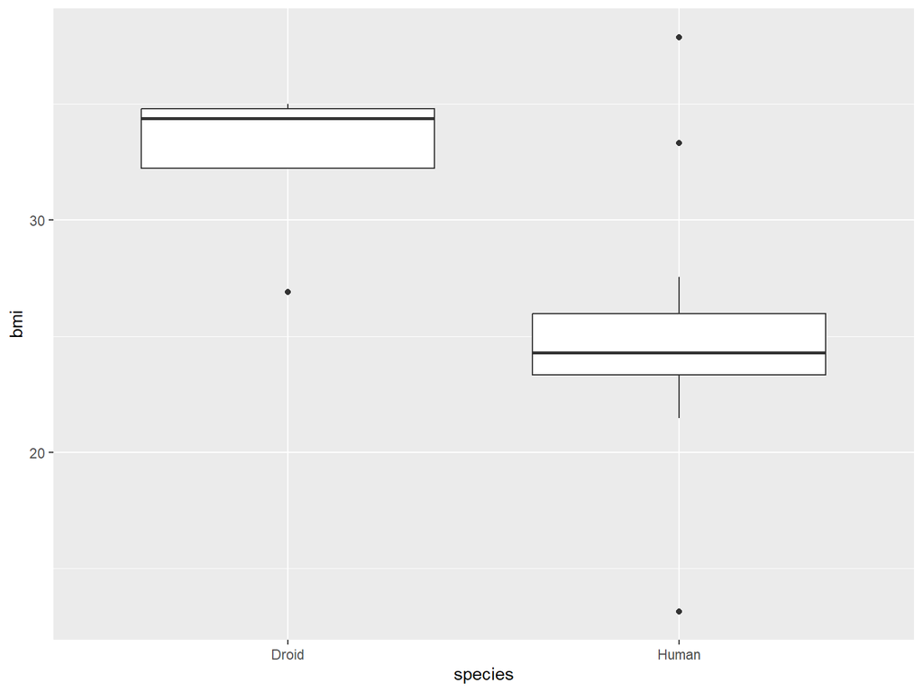

```r
(sw_box1 <- my_starwars_plt |>
  ggplot() +
  geom_boxplot(aes(x=species, y=bmi)))
```

### `fill` option

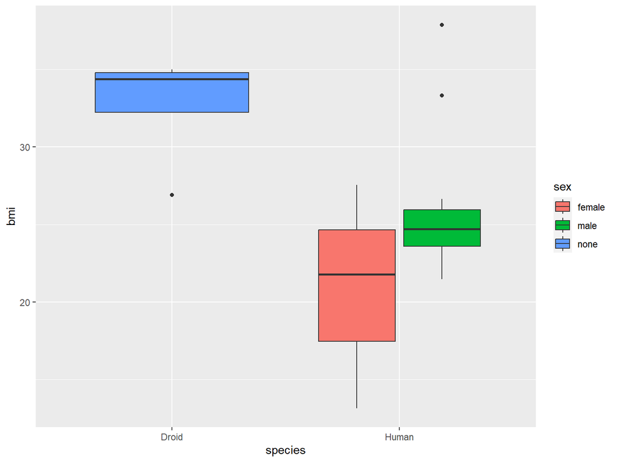

```r
(sw_box2 <- my_starwars_plt |>
  ggplot() +
  geom_boxplot(aes(x=species, y=bmi, fill=sex)))
```